# Week 2 Assignment

Joshua Goldberg

October, 09 2018

**This projects helps understanding how Bayes theorem is used in data analysis**

# 1 Posterior Distribuion for Binomial Model

Repeat calculations of Section 5 of the workshop:

Follow the steps of obtaining posterior distribution by Monte Carlo.

Define likelihood function for binomial distribution.

```r
likeli <- function(par, data) {
  sdata <- sum(data)
  ldata <- length(data)
  return(par ^ sdata * (1 - par) ^ (ldata - sdata))
}
```

Define values of parameter $\theta$ and prior distribution.

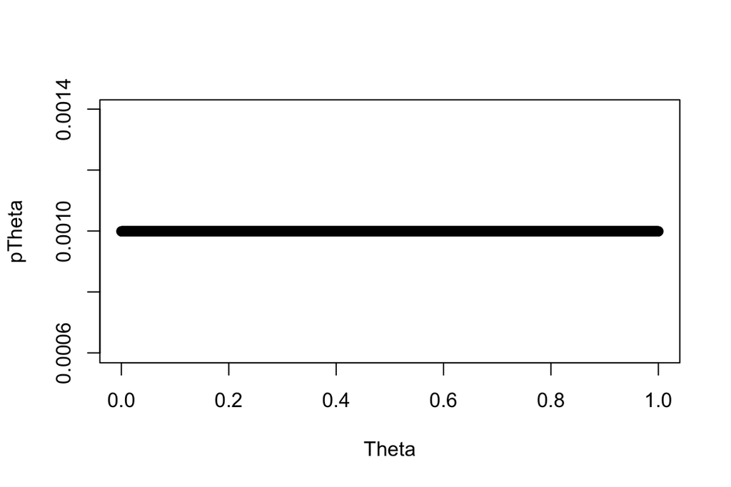

```r
Theta = seq(.00001 , 1 - .00001 , length = 1001) # fine grid for Theta.
pTheta = rep(1, length(Theta))      # Uniform (horizontal) shape for pTheta.
pTheta = pTheta / sum(pTheta)        # Make pTheta sum to 1.0
plot(Theta, pTheta)
```

## 1.1 Find posterior probability for binomial model with uniform prior and data. Use `set.seed(81)` for simulation of $\theta$.

```r
# set.seed(5)
# (Data <- rbinom(5, size = 1, prob = .84))
set.seed(81)
(data1 <- rbinom(10, 1, .71))
```

```
##  [1] 1 0 1 1 0 0 0 1 1 1
```

Create sample of $\theta$ generated from the prior distribution.

```r
set.seed(15)
priorInd <- sample(1:length(Theta), 500, replace = T)
priorSample <- cbind(Theta = Theta[priorInd], Prob = pTheta[priorInd])
priorSample <- rbind(priorSample,
                     c(head(Theta, 1), head(pTheta, 1)),
                     c(tail(Theta, 1), tail(pTheta, 1)))
```

Calculate likelihood for each simulated $\theta$ and the data.

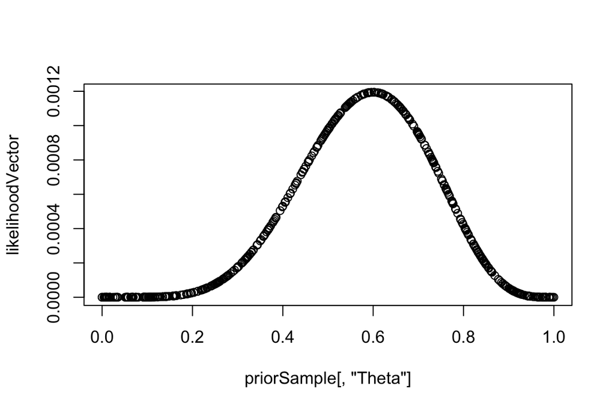

```r
likelihoodVector <- sapply(priorSample[, "Theta"], function(z) likeli(z, data1))
plot(priorSample[, "Theta"], likelihoodVector)
```

Calculate posterior distribution.

- Calculate vector of numerators of the Bayes theorem
- Normalize it
- Create function for linear interpolation of vector of numerator

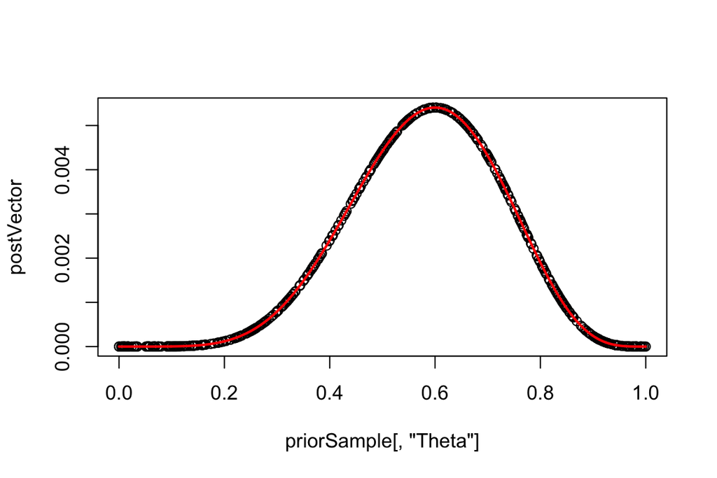

```r
postVector <- priorSample[, "Prob"] * likelihoodVector
postVector <- postVector / sum(postVector)
plot(priorSample[, "Theta"], postVector)

postDistr <- approxfun(priorSample[, "Theta"], postVector, method = "linear")
plot(priorSample[, "Theta"], postVector)
lines(Theta, postDistr(Theta), col = "red", lwd = 2)
```

```r
length(postDistr(Theta))
```

```
## [1] 1001
```

```r
postDistr1 <- postDistr(Theta)
```

Calculate mode, mean and variance of the posterior distribution.

```r
(mode1 <- Theta[which.max(postDistr(Theta))])
```

```
## [1] 0.601998
```

```r
(mean1 <- Theta %*% postDistr(Theta) / sum(postDistr(Theta)))
```

```
##           [,1]
## [1,] 0.5833308
```

```r
(var1 <- ((Theta - mean1)^2) %*% postDistr(Theta) / sum(postDistr(Theta)))
```

```
##            [,1]
## [1,] 0.01869984
```

## 1.2 Add more data and recalculate posterior distribution. Use the `set.seed(97)` for second simulation of $\theta$.

```r
set.seed(97)
pTheta <- postDistr(Theta) / sum(postDistr(Theta))
(data2 <- rbinom(10, 1, .71))
```

```
##  [1] 1 1 0 1 0 0 0 0 1 1
```

Repeat the steps of estimation.

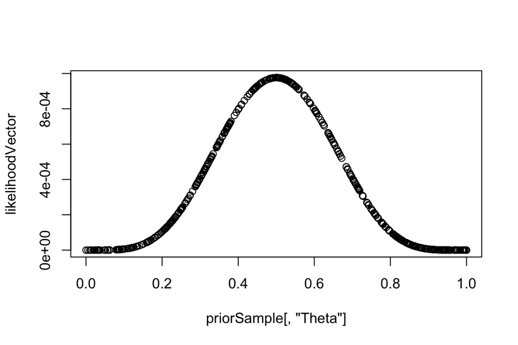

```r
set.seed(35)
priorInd <- sample(1:length(Theta), 500, replace = T)
priorSample <- cbind(Theta = Theta[priorInd], Prob = pTheta[priorInd])
priorSample <- rbind(priorSample,
                     c(head(Theta, 1), head(pTheta, 1)),
                     c(tail(Theta, 1), tail(pTheta, 1)))

likelihoodVector <- sapply(priorSample[, "Theta"], function(z) likeli(z, data2))
plot(priorSample[, "Theta"], likelihoodVector)
```

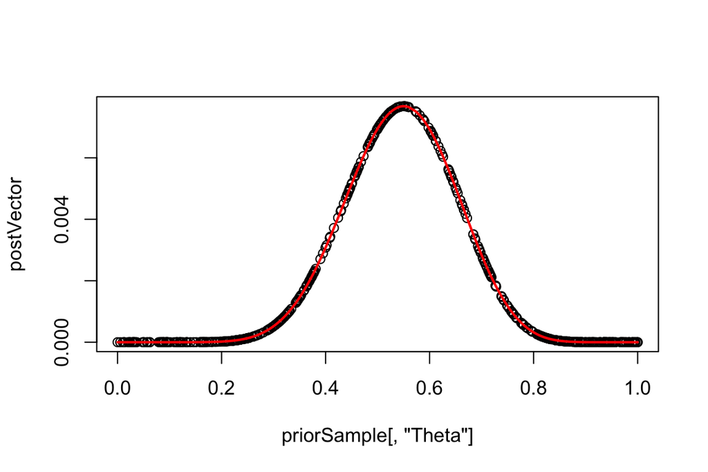

```r
postVector <- priorSample[, "Prob"] * likelihoodVector
postVector <- postVector / sum(postVector)
plot(priorSample[, "Theta"], postVector)

postDistr <-
  approxfun(priorSample[, "Theta"], postVector, method = "linear")
plot(priorSample[, "Theta"], postVector)
lines(Theta, postDistr(Theta), col = "red", lwd = 2)
```

```r
postDistr2 <- postDistr(Theta)
```

Calculate mode, mean and variance of the new posterior distribution.

```r
(mode2 <- Theta[which.max(postDistr(Theta))])
```

```
## [1] 0.550999
```

```r
(mean2 <- Theta %*% postDistr(Theta) / sum(postDistr(Theta)))
```

```
##           [,1]
## [1,] 0.5454514
```

```r
(var2 <- ((Theta - mean2)^2) %*% postDistr(Theta) / sum(postDistr(Theta)))
```

```
##            [,1]
## [1,] 0.01078412
```

Compare the two posteriors.

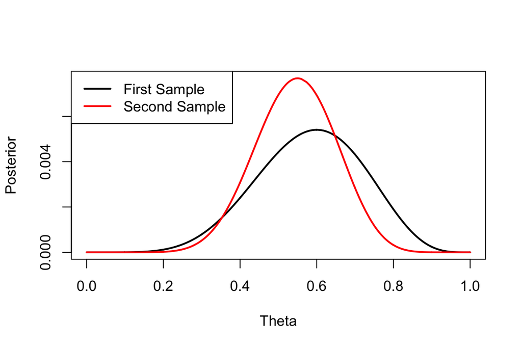

```r
matplot(
  Theta,
  cbind(postDistr1, postDistr2),
  type = "l",
  lty = 1,
  ylab = "Posterior",
  lwd = 2
)
legend(
  "topleft",
  legend = c("First Sample", "Second Sample"),
  lty = 1,
  col = c("black", "red"),
  lwd = 2
)
```

### 1.3 Repeat steps 1. and 2. using data in reverse order: first use `data2`, then add `data1`.

Create sample of $\theta$ generated from the prior distribution.

```r
set.seed(15)
priorInd <- sample(1:length(Theta), 500, replace = T)
priorSample <- cbind(Theta = Theta[priorInd], Prob = pTheta[priorInd])
priorSample <- rbind(priorSample,
                     c(head(Theta, 1), head(pTheta, 1)),
                     c(tail(Theta, 1), tail(pTheta, 1)))
```

Calculate likelihood for each simulated $\theta$ and the data.

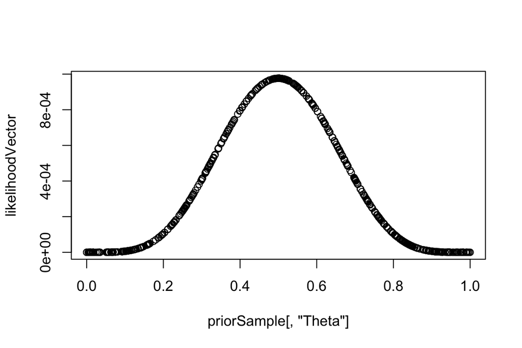

```r
likelihoodVector <- sapply(priorSample[, "Theta"], function(z) likeli(z, data2))
plot(priorSample[, "Theta"], likelihoodVector)
```

Calculate posterior distribution.

- Calculate vector of numerators of the Bayes theorem
- Normalize it
- Create function for linear interpolation of vector of numerator

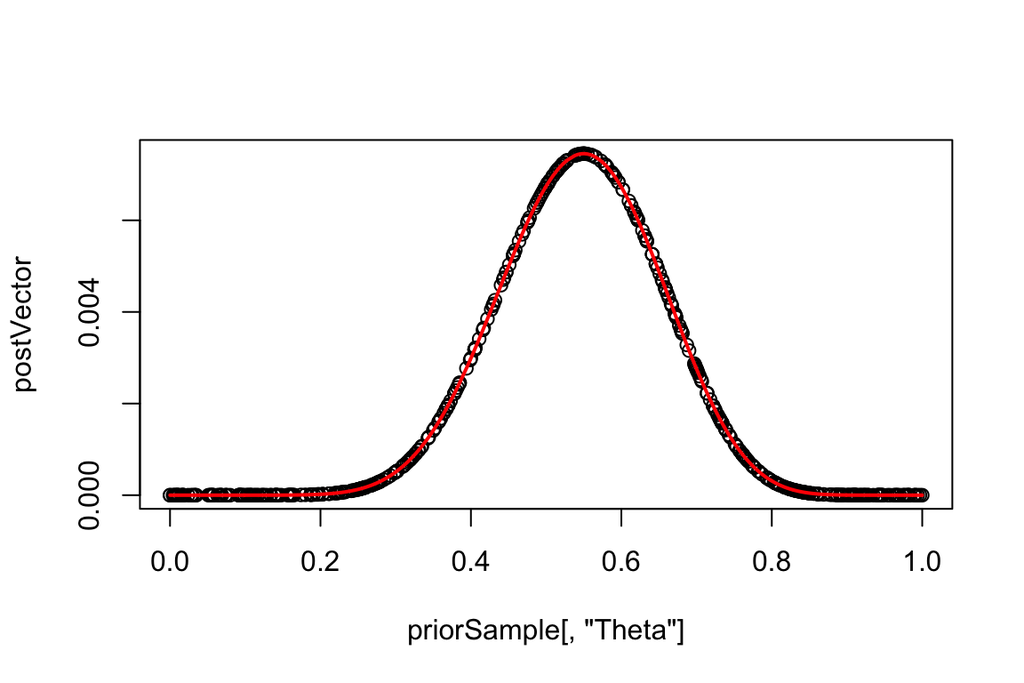

```r
postVector <- priorSample[, "Prob"] * likelihoodVector
postVector <- postVector / sum(postVector)
plot(priorSample[, "Theta"], postVector)

postDistr <- approxfun(priorSample[, "Theta"], postVector, method = "linear")
plot(priorSample[, "Theta"], postVector)
lines(Theta, postDistr(Theta), col = "red", lwd = 2)
```

```r
length(postDistr(Theta))
```

```
## [1] 1001
```

```r
postDistr3 <- postDistr(Theta)
```

Calculate mode, mean and variance of the posterior distribution.

```r
(mode3 <- Theta[which.max(postDistr(Theta))])
```

```
## [1] 0.550999
```

```r
(mean3 <- Theta %*% postDistr(Theta) / sum(postDistr(Theta)))
```

```
##           [,1]
## [1,] 0.5454511
```

```r
(var3 <- ((Theta - mean3)^2) %*% postDistr(Theta) / sum(postDistr(Theta)))
```

```
##            [,1]
## [1,] 0.01078276
```

Repeat the steps of estimation.

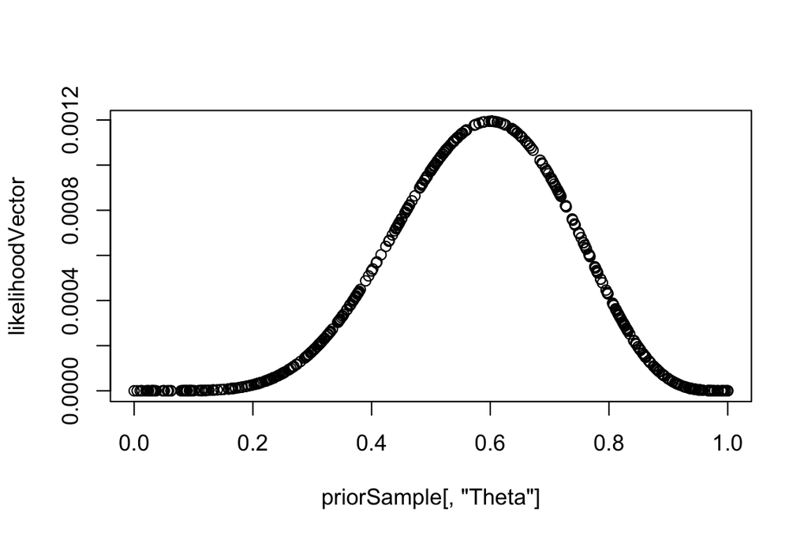

```r
set.seed(35)
priorInd <- sample(1:length(Theta), 500, replace = T)
priorSample <- cbind(Theta = Theta[priorInd], Prob = pTheta[priorInd])
priorSample <- rbind(priorSample,
                     c(head(Theta, 1), head(pTheta, 1)),
                     c(tail(Theta, 1), tail(pTheta, 1)))

likelihoodVector <- sapply(priorSample[, "Theta"], function(z) likeli(z, data1))
plot(priorSample[, "Theta"], likelihoodVector)
```

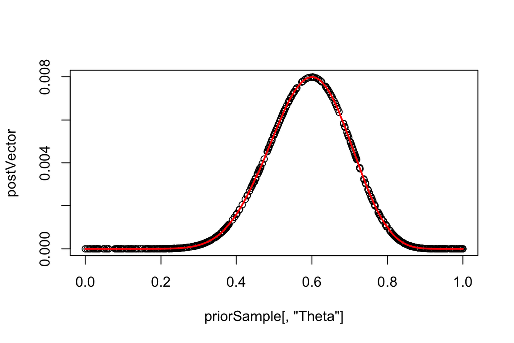

```r
postVector <- priorSample[, "Prob"] * likelihoodVector
postVector <- postVector / sum(postVector)
plot(priorSample[, "Theta"], postVector)

postDistr <-
  approxfun(priorSample[, "Theta"], postVector, method = "linear")
plot(priorSample[, "Theta"], postVector)
lines(Theta, postDistr(Theta), col = "red", lwd = 2)
```

```r
postDistr4 <- postDistr(Theta)
```

Calculate mode, mean and variance of the new posterior distribution.

```r
(mode4 <- Theta[which.max(postDistr(Theta))])
```

```
## [1] 0.601998
```

```r
(mean4 <- Theta %*% postDistr(Theta) / sum(postDistr(Theta)))
```

```
##           [,1]
## [1,] 0.5909058
```

```r
(var4 <- ((Theta - mean4)^2) %*% postDistr(Theta) / sum(postDistr(Theta)))
```

```
##            [,1]
## [1,] 0.01051471
```

Compare the two posteriors.

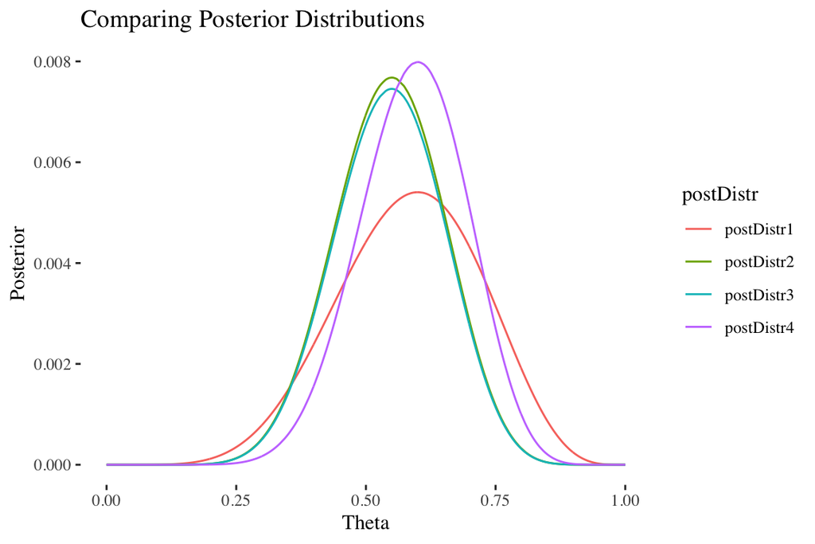

```r
data.frame(postDistr1, postDistr2, postDistr3, postDistr4, Theta) %>%
  gather(key = postDistr, value = value, -5) %>%
  ggplot(aes(Theta, value, color = postDistr)) +
  geom_line() +
  labs(title = "Comparing Posterior Distributions",
       x = "Theta",
       y = "Posterior") +
  ggthemes::theme_tufte()
```

```r
(result <- data.frame(postDistr = c(1, 2, 3, 4),
          mode = rbind(mode1, mode2, mode3, mode4),
          mean = rbind(mean1, mean2, mean3, mean4),
          var = rbind(var1, var2, var3, var4)) %>%
  as_tibble())
```

|  | postDistr | mode | mean | var |
| --- | --- | --- | --- | --- |
| 1 | 1 | 0.601998 | 0.5833308 | 0.01869984 |
| 2 | 2 | 0.550999 | 0.5454514 | 0.01078412 |
| 3 | 3 | 0.550999 | 0.5454511 | 0.01078276 |
| 4 | 4 | 0.601998 | 0.5909058 | 0.01051471 |